# Bayesian Trend Filtering

Edward A. Roualdes

2015-04-03

## Introduction

Bayesian trend filtering estiamtes the function $f = f(x_1), \ldots, f(x_n)$ from data $y_i, i=1, \ldots, n$, hypothesized to be generated from the model $y_i = f(x_i) + \epsilon_i$ by fitting a fully Bayesian hierarchical model that is equivalent to the minimization problem $argmin_f ||y - f||_2^2 + \lambda||D^k f||_1$ as detailed by R.J. Tibshirani (2014). The penalty matrix $D^k$ estimates $k$th derivatives of $f$ at various inputs $x_i$. This is the Bayesian analogue to the function [`genlasso::trendfilter`](http://cran.r-project.org/web/packages/genlasso/index.html).

The main function of this package, `btf::btf`, assumes the inputs $x_i, i=1, \ldots, n$, are equally spaced and in ascending order. The user needs to specify the order of the derivatives $k$. I recommend $k<=3$ since calculations with $D^k$ can otherwise cause numerical instability. Note that unlike `genlasso::trendfilter` Bayesian trend filtering will not set any elements of the penalty vector $D^k f$ exactly equal to zero and thus this method should be used as a smoother.

## Fitting btf

We’ll use the time-series observations `datasets::nhtemp`. First, fit a model by specifying the observations $y$ and the order of the derivative to use.

```r
library(btf)
fit <- btf(nhtemp, k=3)
```

The variable `fit` is nothing special, but I recommend retrieving the posterior samples with the functions `btf::getPost`. You can specify which parameter you want to investigate, by default we assume you are interested in the estimate of $f$. Output from this function is a `coda::mcmc` object, suitable for any of the methods specified within the [`coda`](http://cran.r-project.org/web/packages/coda/index.html) package.

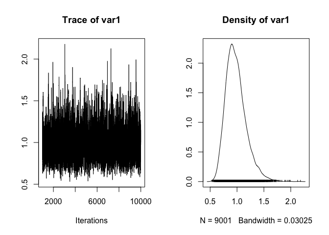

```r
plot(getPost(fit, 's2'))
```

Alternatively, you can ask for a summary of the parameters requested. The function `btf::getPostEst` will give the output from `coda::summary.mcmc` applied to the parameters specified, or $f$ is no paramters are specified. You can also specify a function be applied to each of the paramters requested.

```r
getPostEst(fit, 's2')
```

```
##
## Iterations = 1000:10000
## Thinning interval = 1
## Number of chains = 1
## Sample size per chain = 9001
##
## 1. Empirical mean and standard deviation for each variable,
##    plus standard error of the mean:
##
##           Mean             SD       Naive SE Time-series SE
##       0.980370       0.189247       0.001995       0.003568
##
## 2. Quantiles for each variable:
##
##   2.5%    25%    50%    75%  97.5%
## 0.6813 0.8477 0.9565 1.0839 1.4213
```

```r
getPostEst(fit, 's2', est=mean)
```

```
##      var1
## 0.9803698
```

A simple plot of the estimate of $f$ and highest posterior density intervals is provided by the S3 method `btf::plot.btf`

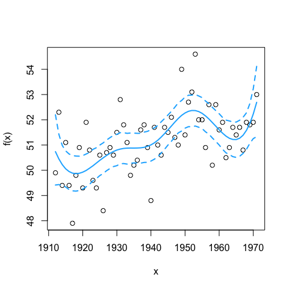

```r
plot(fit)
```

References

Tibshirani, Ryan J. 2014. “Adaptive Piecewise Polynomial Estimation via Trend Filtering.” *The Annals of Statistics* 42 (1). Institute of Mathematical Statistics: 285–323.